# Minimal Residual Disease in ALL – First Round Survey Results

## 7.3 Which pull of the bone marrow aspiration is used for MRD detection during follow-up?

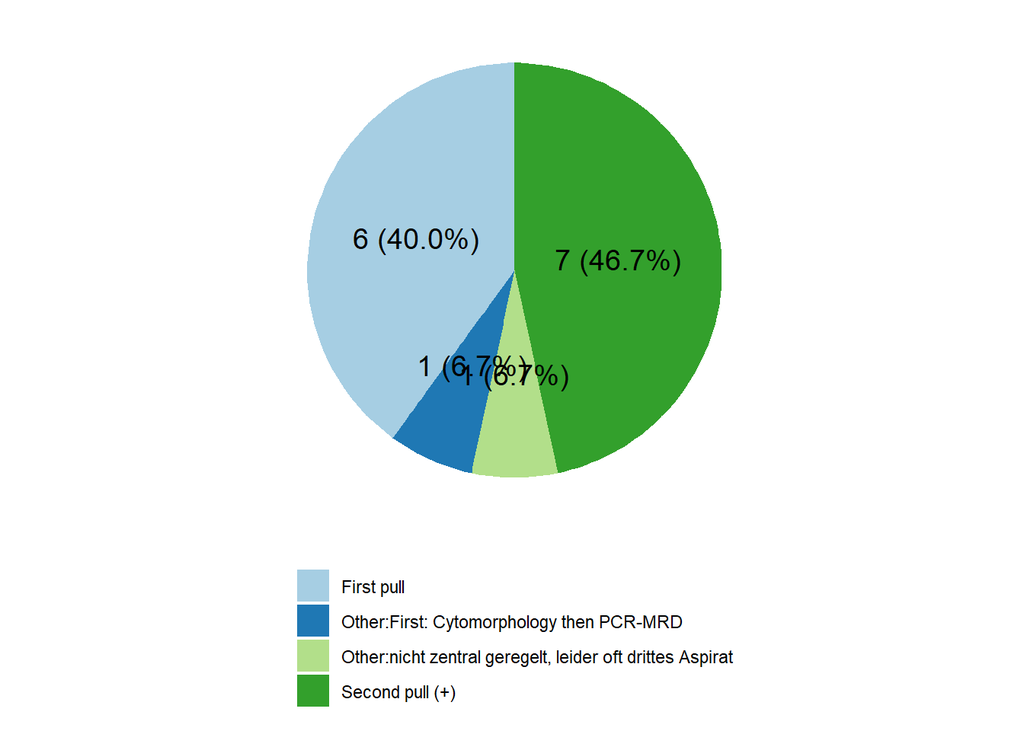

Statement 17: For MRD assessment, a first-pull bone marrow aspirate of 2–5 mL should be requested.

## 7.4 If the first pull of bone marrow aspiration is not used for MRD assessment, what is it typically used for?

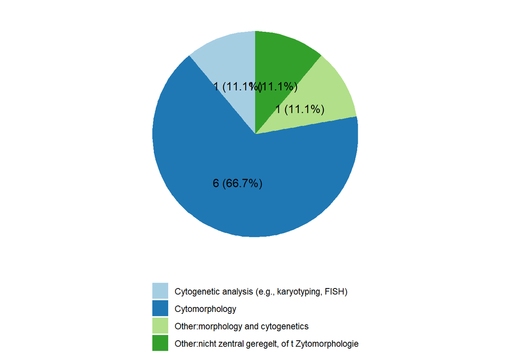

Statement 18: The first pull of bone marrow aspiration should be used for MRD assessment, as hemodilution in later pulls may hamper accurate MRD quantification.

## 7.5 What collection system do you use for bone marrow aspiration?

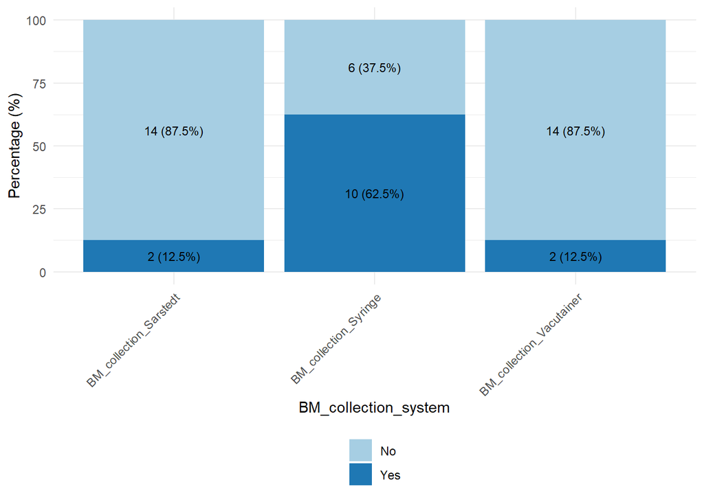

| Response | Answer |
| --- | --- |
| Other | See Kiel SOP |
| Other | Don’t know if it is standardized |
| Other | do not know and I am afraid to go ask somewhere because it seems impossible to save the answers and I would loose too much work |
| Other | systems differ between clinical departments |

## 7.6 What is the volume of the collection system you use for bone marrow aspiration?

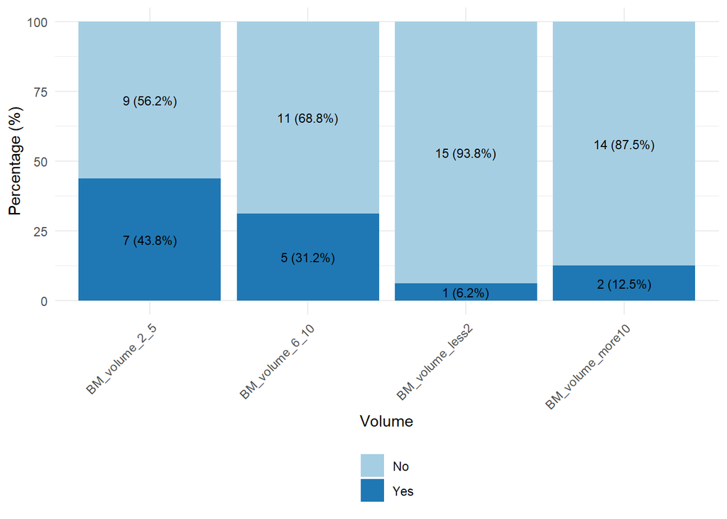

| Response | Answer |
| --- | --- |
| Other | not applicable |
| Other | 2-5 ml left and 2-5 ml right |
| Other | nicht zentral geregelt |
| Other | depending of age and collection system all of the answers above |

## 7.7 What volume of bone marrow do you typically aspirate during the procedure?

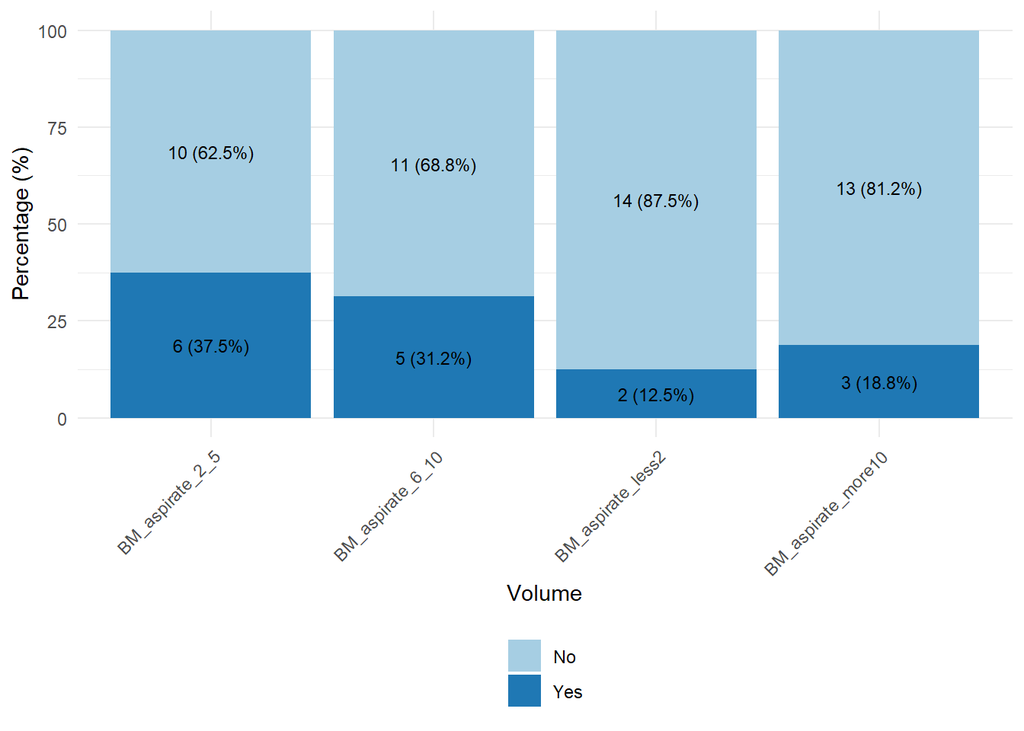

| Response | Answer |
| --- | --- |
| Other | in multiple aspirates |
| Other | Following the SOP , we perform 2 aspirates of 4ml (1st aspirate) and 10ml (2nd aspirate at different angle through same skin puncture) |
| Other | we do repeat pulls of approximately 2ccs with reanchoring |
| Other | nicht zentral geregelt,oft 2-5 ml |
| Other | depending of age and collection system all of the answers above |

## 7.8 What volume of bone marrow do you typically provide for MRD analysis?

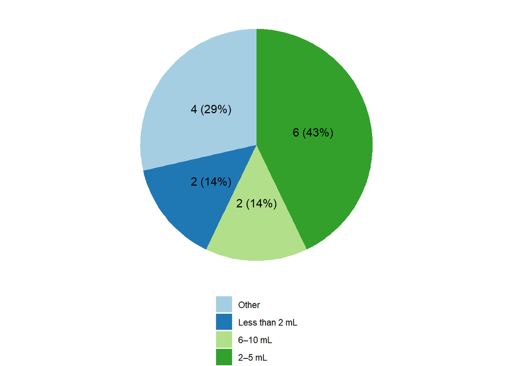

| Category | Comment |
| --- | --- |
| Other | we receive DNA already extracted |
| Other | Optimally 2.0 mL |
| Other | depends on the cell number |
| Other | nicht zentral geregelt, oft 2-5 ml |
| 6–10 mL | depending of age and collection system all of the answers above |

Statement 19: Up to 10mL of bone marrow should be aspirated in the first pull, of which 2–5mL should be provided for MRD analysis.

# 8 Trephine biopsy

## 8.1 Do you perform bone marrow trephine biopsy?

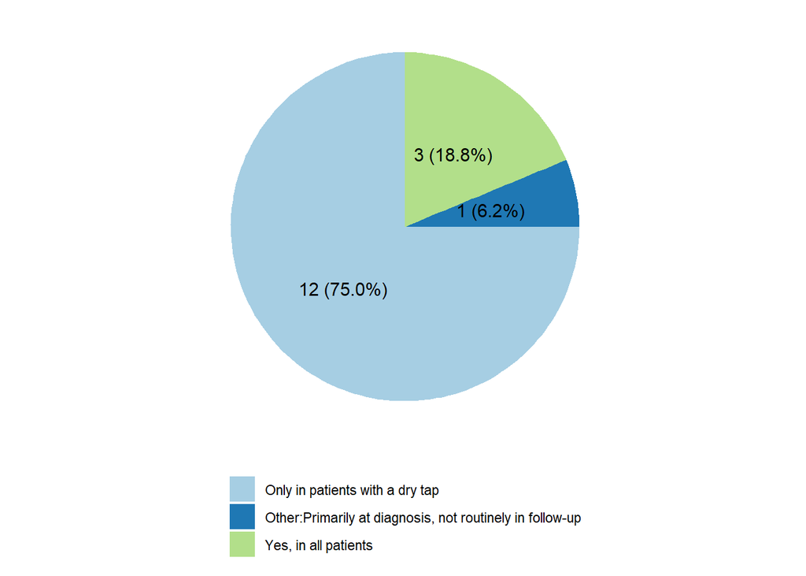

## 8.2 What is your typical approach in cases of a dry tap during bone marrow aspiration?

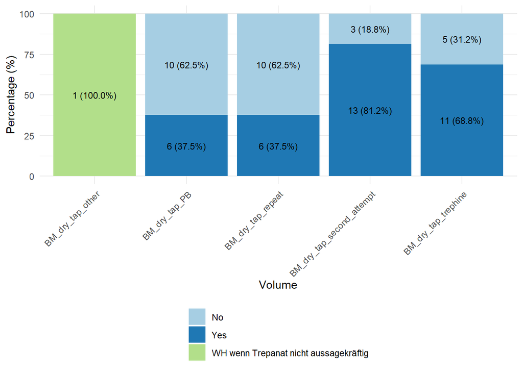

Statement 20: In the case of a dry tap during bone marrow aspiration, a trephine biopsy should be performed.

Statement 21: In the case of a dry tap during bone marrow aspiration, a second aspiration should be attempted at a different site.

Statement 22: In the case of a dry tap during bone marrow aspiration, a trephine biopsy is a suitable alternative for molecular MRD analysis.

# 9 Transport times

## 9.1 What is the typical transport time for bone marrow samples used for **molecular** MRD analysis?

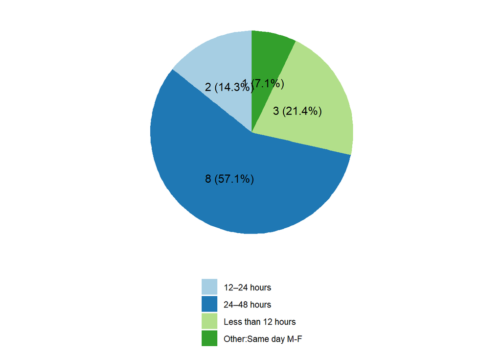

Statement 23: The transport time for bone marrow samples intended for molecular MRD analysis is not critical.

## 9.2 What is the typical transport time for bone marrow samples used in **flow cytometry** MRD analysis?

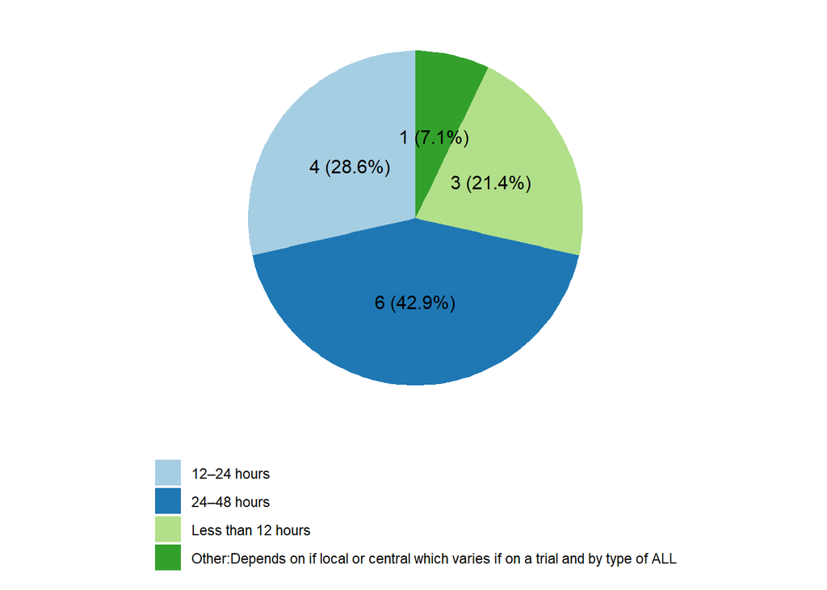

Statement 24: Bone marrow samples intended for flow cytometry MRD analysis should be processed within 3 days (stored undiluted at ambient temperature); if stored for more than 3 days, the MRD report should note the potential for compromised cell viability.

# 10 Sample preparation

## 10.1 Are your bone marrow samples being checked for hemodilution?

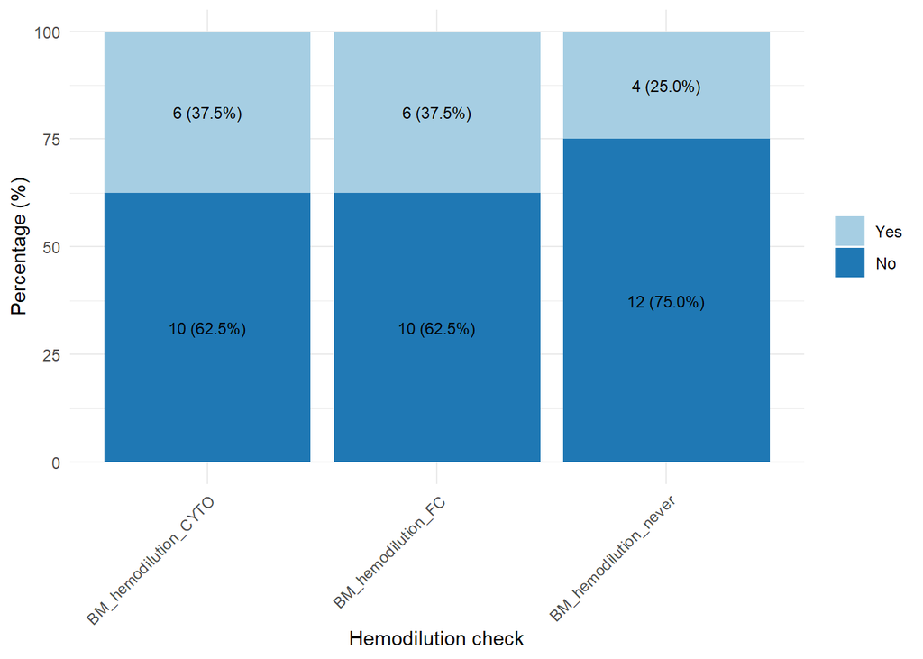

| Category | Comment |
| --- | --- |
| No, never | We send the sample to the central lab for FCM and there check for hemodilution |
| Yes, using Cytomorphology | Presence/absence of bone marrow particles |
| Yes, using Cytomorphology | assessment of spicules |
| Yes, using Cytomorphology | Important for remission evaluation at day 33 (TP1) |
| Yes, using Flow cytometry | checked for but no calculation, remark made in conclusion |
| Yes, using Flow cytometry | do not know and do not want to go ask FC guys because it seems impossible to save the answers in the process. can send later |
| Yes, using Flow cytometry | Presence of <2% of EBL |
| Yes, using Flow cytometry | Only day 15: Important for FCM-MRD evaluation |

## 10.2 If your bone marrow samples are assessed for hemodilution, how do you utilize the obtained information?

- only remark with warning in conclusion
- The test is performed anyway, final evaluation with the physician
- A new sample is performed in case of hemodilution
- write a comment to the results
- If high-risk criteria are fulfilled (depending on the TP), resuts will be released for clinical used but withhold by the lab below those limits.
- A comment is detailed in the cytomorphology report.
- We might repeat depending on how much the result impacts clinical care.
- Generally still used but with note made of hemodilution
- Hemodilution is mostly relevant fror Response Evaluation at day 33 (TP1). If cytomorphology showes signs of heodilution and therefore a not representative BM, the BM puncture should be repeated. However we always measure MRD in both samples and use the higher value for stratification, because unsually MRD-levels are decreasing even without continuation of therapy after Day 33.

Statement 25: Bone marrow samples should be checked for hemodilution using either cytomorphology or flow cytometry; if hemodilution is detected, it should be noted in the report.

## 10.3 Are your bone marrow samples being processed using Ficoll separation prior to MRD analysis?

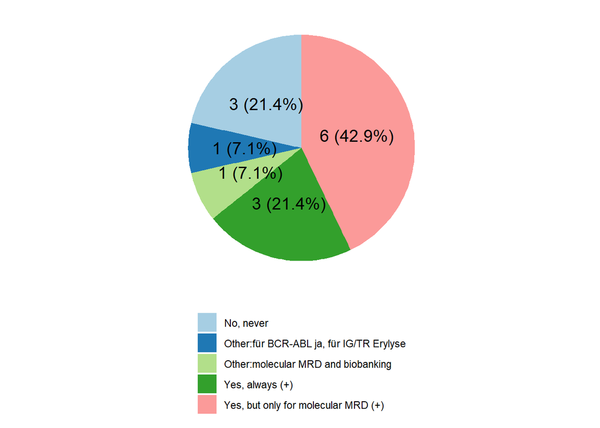

Statement 26: Ficoll separation should not be performed prior to MRD analysis, but may be used if cells are planned to be stored for future use.

## 10.4 When preparing the first dilution step (typically 1E-01) for the standard curve from a Ficoll-processed sample, do you take the blast percentage into account?

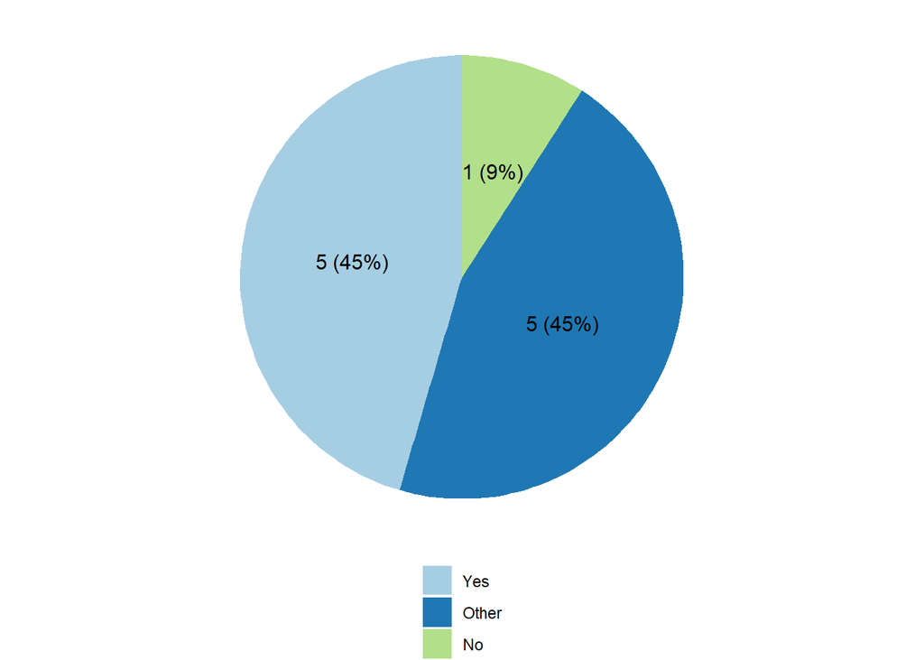

| Category | Comment |
| --- | --- |
| Other | yes, when blasts are below 50% |
| Other | yes if it is below 50% |
| Other | this varies based on each center practice |
| Other | für IG/TR ja, für BCR-ABL nein |
| Other | we adjust the standard curve according to cytomorphology, if blast infiltration is below 50% however we are trying to implement Flow after Ficoll at the moment in order to be more exact |

Statement 27: When preparing the first dilution step (typically 1×10⁻¹) for the qPCR standard curve from a Ficoll-processed sample, the blast percentage should always be taken into account.

## 10.5 Is flow cytometry analysis performed before or after Ficoll separation?

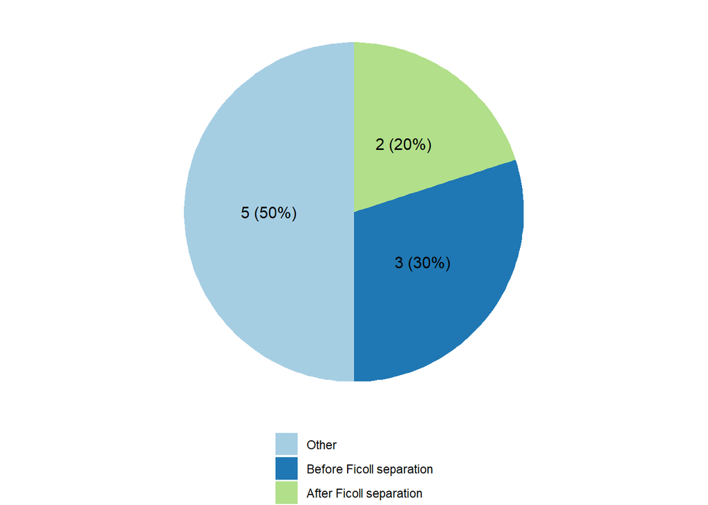

| Category | Comment |
| --- | --- |
| Other | I do not know |
| Other | and after for defining blast percentage for molecular standard curve |
| Other | before, in some situations (low number of blasts, sorting for RNAseq) later |
| Other | The complete Flow cytometry analysis is performed before Ficoll separation. After Ficoll separation we perform an additional tube to calculate the blast percentage post-Ficoll |
| Other | planned: after ficoll |

Statement 28: Flow cytometry MRD analysis should be performed before Ficoll separation.

Statement 29: Flow cytometry MRD analysis should be performed after Ficoll separation.

## 10.6 Is cytomorphology analysis performed before or after Ficoll separation?

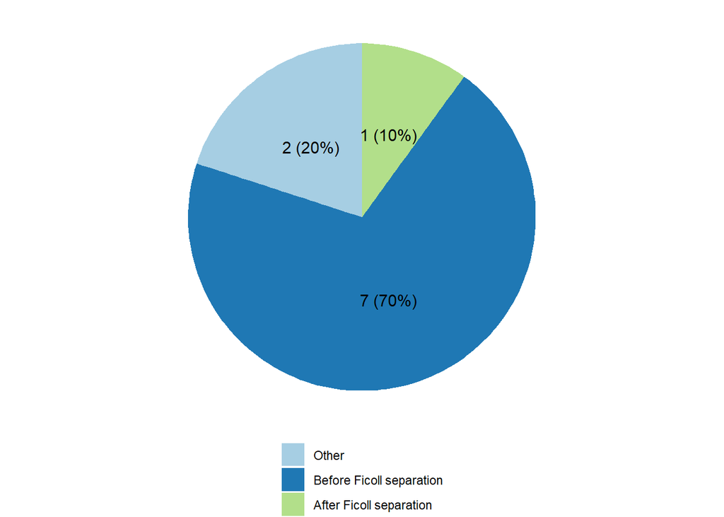

| Category | Comment |
| --- | --- |
| Other | not performed |
| Other | cytomorphology is performed on BM smears and not in the same sample |

Statement 30: Cytomorphology analysis should be performed before Ficoll separation.

# 11 MRD assesment methods

## 11.1 Which method(s) do you employ for MRD assesment in **Ph-neg, KMT2A-neg BCP-ALL**?

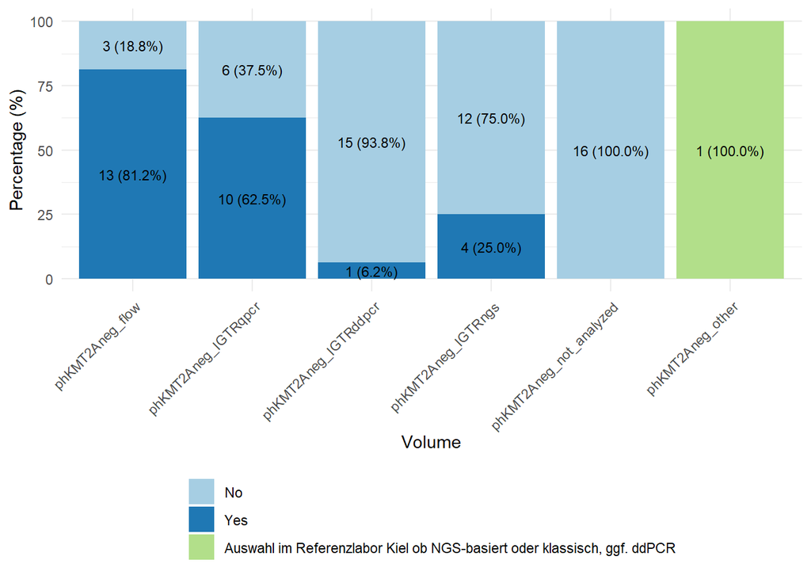

## 11.2 Which method(s) do you employ for MRD assesment in **Ph-positive BCP-ALL**?

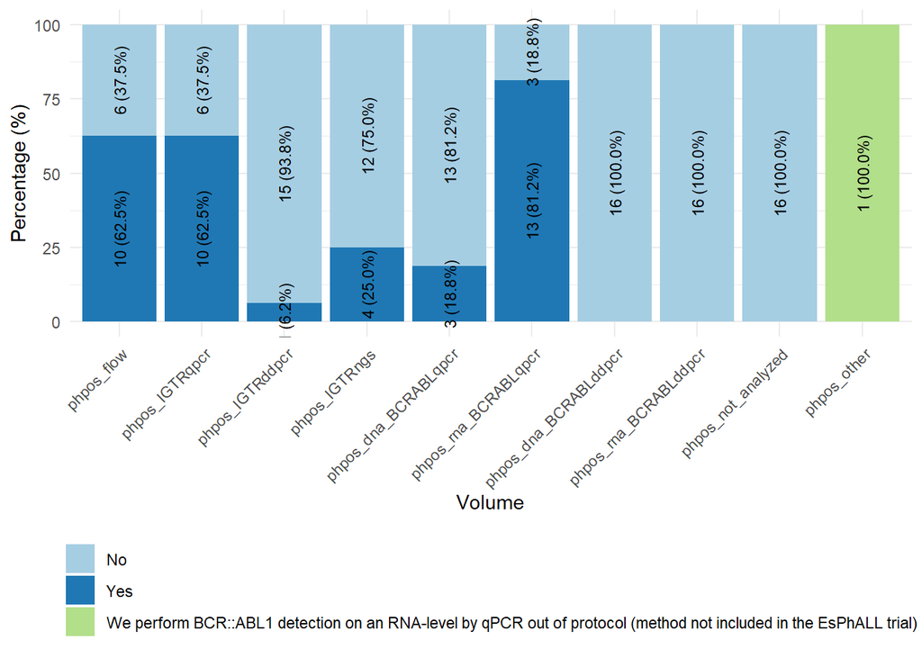

## 11.3 Which method(s) do you employ for MRD assesment in **KMT2A-positive BCP-ALL**?

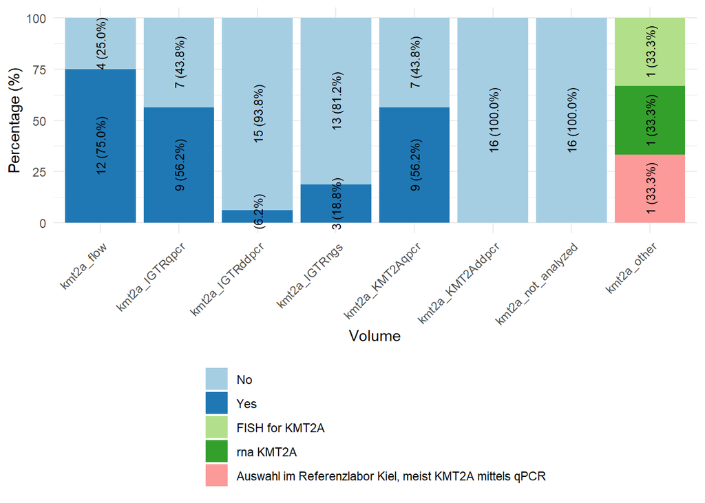

## 11.4 Which method(s) do you employ for MRD assesment in **T-ALL**?

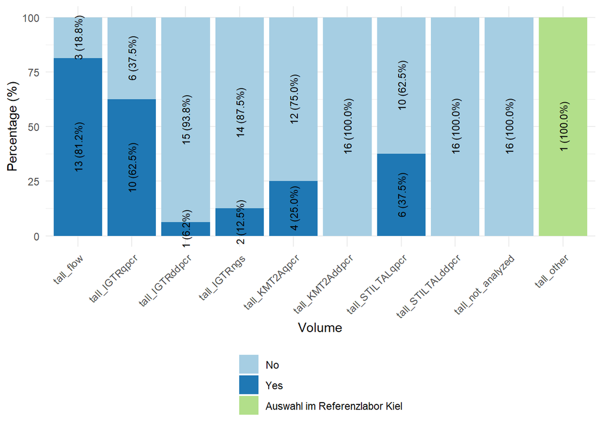

## 11.5 Do you use any molecular markers for MRD analysis other than those mentioned above?

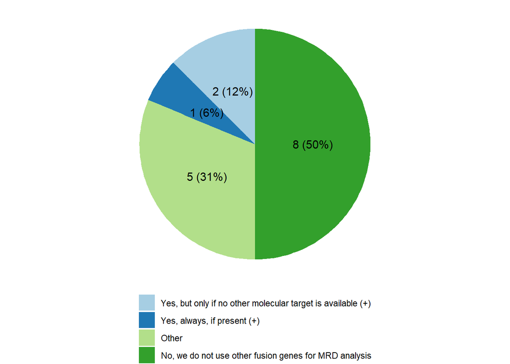

| Category | Comment |
| --- | --- |
| Other | depends on target, number of classical targets |
| Other | no, not at the moment |
| Other | If flow unavailable |
| Other | SIL-TAL and IKZf1 |
| Other | Auswahl im Referenzlabor Kiel |

## 11.6 Which additional molecular markers do you use for MRD analysis?

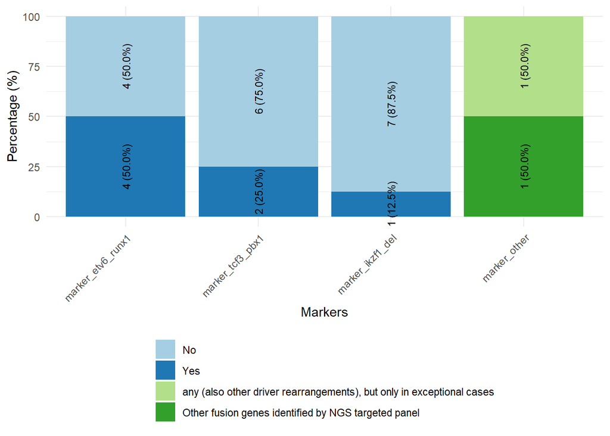

# 12 Technical requirements flow cytometry

## 12.1 Which anticoagulant do you use for bone marrow samples intended for flow-cytometry MRD analysis?

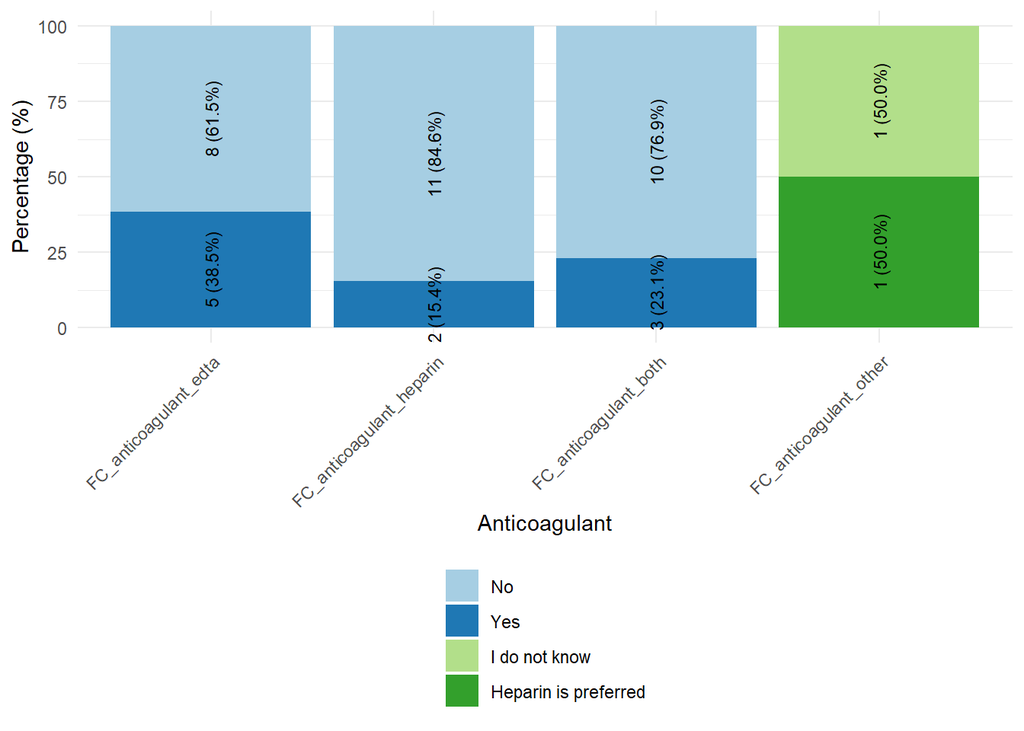

Statement 31: Bone marrow samples intended for flow cytometry MRD analysis should be collected using either heparin or EDTA as an anticoagulant.

## 12.2 Do you apply bulk lysis to your samples?

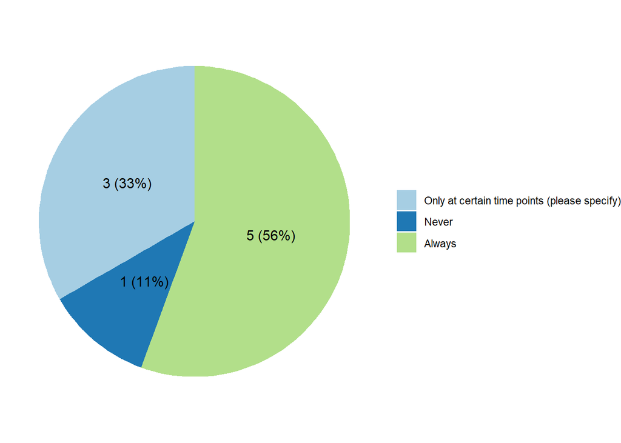

| Category | Comment |
| --- | --- |
| NA | I do not know |
| Only at certain time points (please specify) | Not in aplasia |
| Only at certain time points (please specify) | in case of low cellularity |
| NA | Sometimes |
| Only at certain time points (please specify) | only remission samples (day 33 onwards), not day 15 and not inital diagnosis |

Statement 32: Bulk lysis should be applied to bone marrow samples prior to flow cytometry analysis.

## 12.3 What is the minimum number of cells you typically measure?

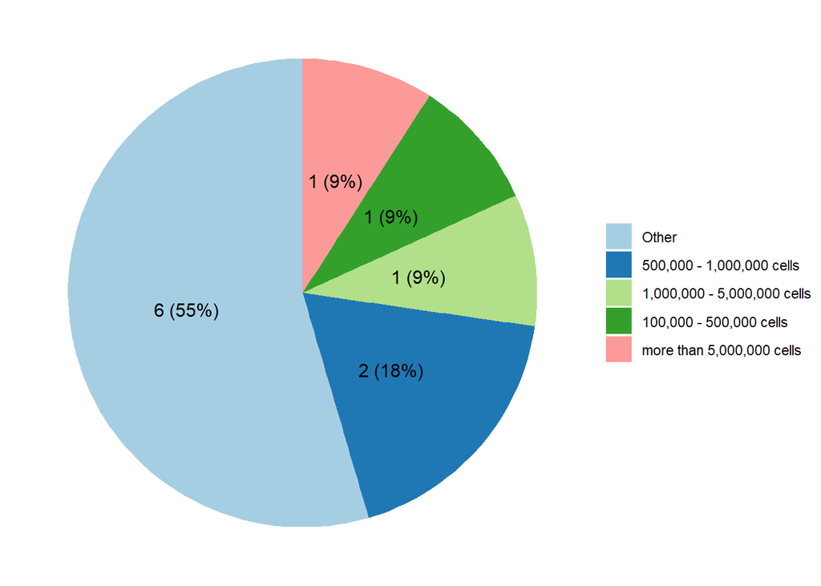

| Category | Comment |
| --- | --- |
| Other | I do not know ( I am clinician) |
| Other | Depends on the time-point. In ALL-BFM, we do day 15 MRD, and there we acquire 500,000 cells. In GMALL and in ALL-BFM at other time-points, we aim for 4,000,000 events. |
| Other | Dx 100,000, day 15 100,000-500,000, day 33 more than 1,000,000 |
| Other | 500,000 cells |
| Other | Varies based on lab and method |
| Other | remission spamples:1-10. Mio, Initial + day 15 : 100.000-500,000 |

## 12.4 What is the minimum number of events required to define MRD positivity (LOD)?

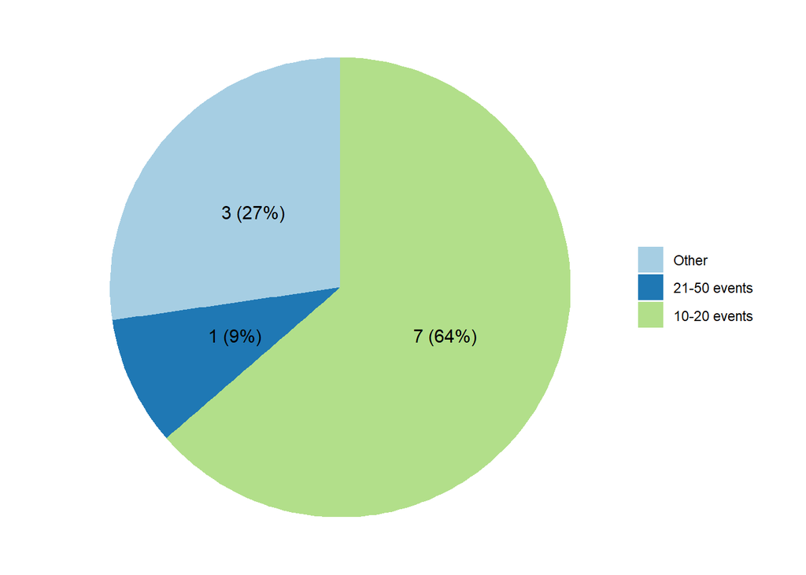

| Category | Comment |
| --- | --- |
| Other | do not know ( I am clinician) |
| Other | 10 events |
| Other | Varies based on lab and method |

## 12.5 What is the minimum number of events required to quantify MRD (LOQ)?

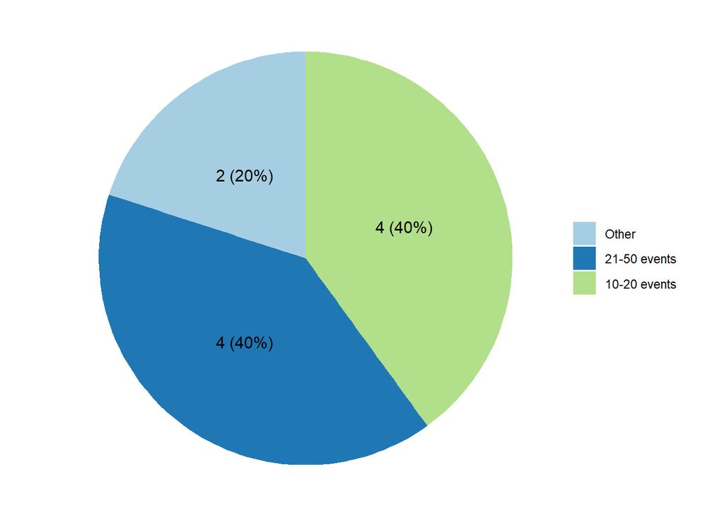

| Category | Comment |
| --- | --- |
| NA | do not know ( I am clinician) |
| Other | 40 events |
| Other | Varies based on lab and method |

## 12.6 What level of sensitivity (LOD) is typically achieved in your MRD analysis?

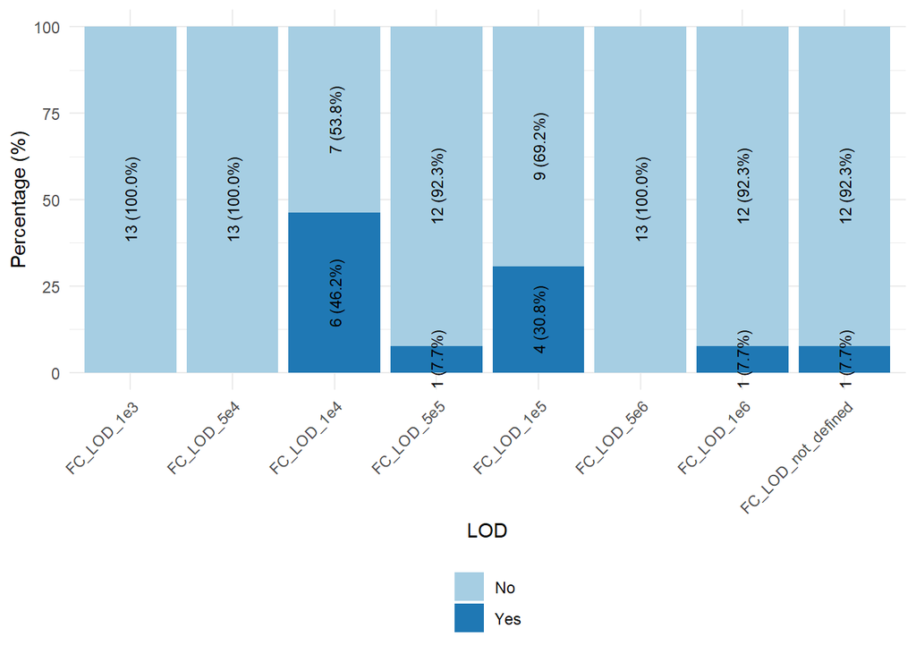

| Response | Answer |
| --- | --- |
| Other | BCP-ALL: E-05, T-ALL: rather E-04 or less |
| Other | depends on timepoint, see above |
| Other | 2X10-5 |
| Other | It varies according to the time point |
| Other | day 15: 1E-03 (without bulk lyisis) |

## 12.7 What level of quantification (LOQ) is typically achieved in your MRD analysis?

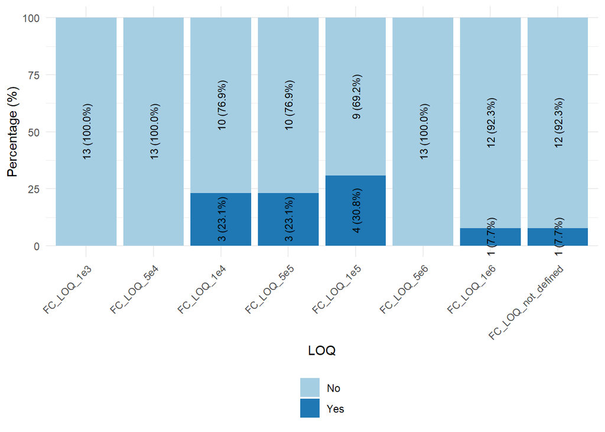

| Response | Answer |
| --- | --- |
| Other | BCP-ALL: 5xE-05, T-ALL: rather E-04 or less |
| Other | day 15 0.1%, day 33 0.1%-0.01% |
| Other | 6X10-5 |
| Other | It varies according to the time point |

## 12.8 Do you use a commercial assay or an in-house assay for your MRD analysis?

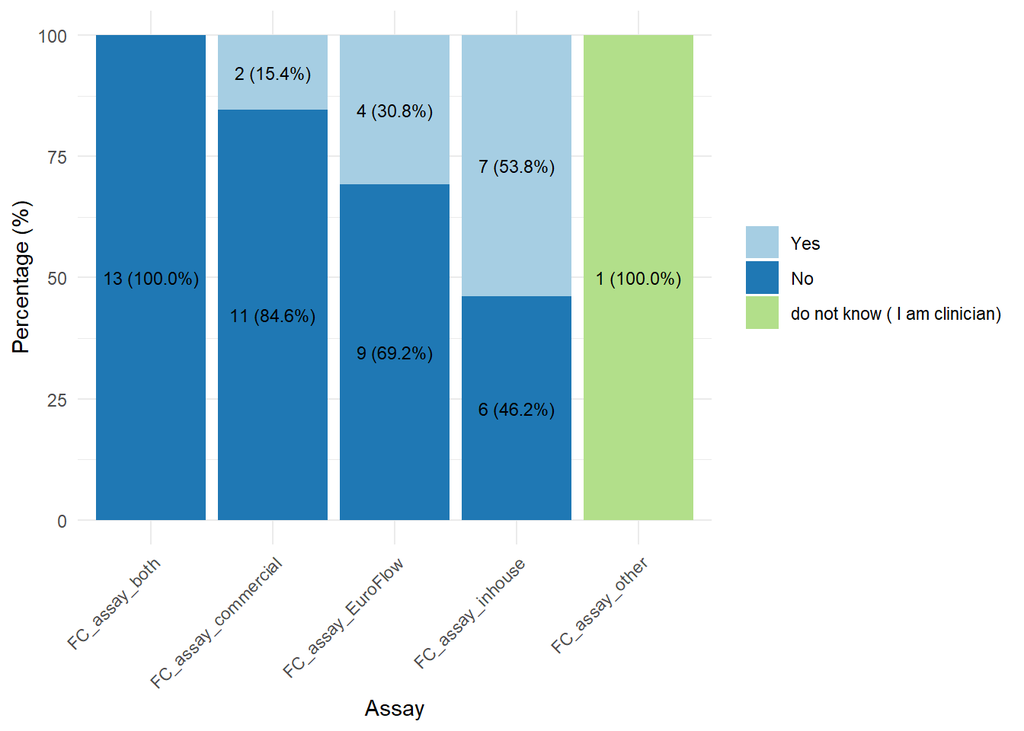

| Category | Comment |
| --- | --- |
| Commercial | NSG MRD is commercial |
| Commercial | ClonoSeq for NGS-based |
| EuroFlow | BCP-ALL: EuroFlow, but as in-house assay. T-ALL: in-house assay according to BFM-Flow SOP |
| EuroFlow | BCP-ALL MRD assay |
| EuroFlow | BD CytognosTM B-cell Precursors ALL MRD |
| EuroFlow | B-MRD plus 1 additional in-house tube |
| In-house | I-BFM standard |
| In-house | Flow is both performed locally and centrally and depends on population and trial and timepoints |
| In-house | St. Jude in house |
| In-house | T-MRD |

# Statements all MRD methods

Statement 33: For clinical decision-making, MRD assessment should be performed using a validated assay.

Statement 34: A standardized MRD assay nomenclature should be used, where ‘Flow-MRD4/5/6’ refers to flow cytometry-based MRD with defined sensitivity, and ‘IG/TR-MRD4/5/6’, ‘KMT2A-MRD4/5/6’, or ‘BCR::ABL1-MRD4/5/6’ refer to molecular MRD assays targeting specific genes, with the suffix indicating detection limit (e.g., IG/TR-MRD5 = 1×10⁻⁵).

Statement 35: At each MRD timepoint, the most appropriate assay (e.g., Flow-MRD4, IG/TR-MRD5, etc.) should be selected based on the availability of a suitable molecular or immunophenotypic marker and the sensitivity required for clinical decision-making.

Statement 36: The limit of detection (LOD) for each MRD assay should be determined based on the number of cells or cell equivalents analyzed and the level of background signal.

Statement 37: The limit of quantification (LOQ) should be assessed individually for each MRD assay to ensure reliable quantification of low-level disease.

Statement 38: For molecular assays, the number of amplifiable DNA copies should be calculated by dividing the input DNA amount by 6.5 pg (average DNA content per cell); for example, 1 µg of amplifiable DNA corresponds to approximately 150,000 DNA copies.

Statement 39: For BCR::ABL1-based MRD analysis using RNA as material, the copy number of a housekeeping gene such as ABL or GUS should be assessed to estimate the input material and ensure accurate quantification.

# Statements all molecular methods

Statement 40: Bone marrow samples intended for IG/TR qPCR MRD analysis should be collected using EDTA as an anticoagulant.

Statement 41: IG/TR-based qPCR/ddPCR and NGS yield comparable MRD values within the respective limits of detection and quantification, provided that a validated assay is used.

Statement 42: Prior to any molecular MRD analysis, a quantitative control of DNA amplifiability should be performed, and a remark should be included in the report if amplifiability is insufficient.

# 13 Technical requirements IG/TR qPCR

## 13.1 Which anticoagulant do you use for bone marrow samples intended for IG/TR-based qPCR MRD analysis?

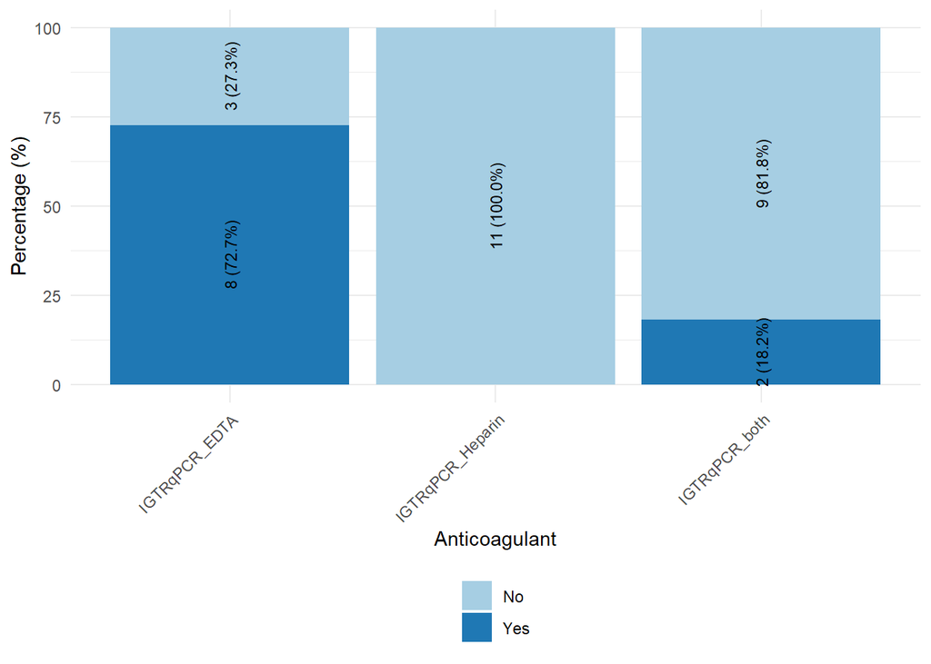

## 13.2 What is the minimum DNA amount you typically analyze per reaction?

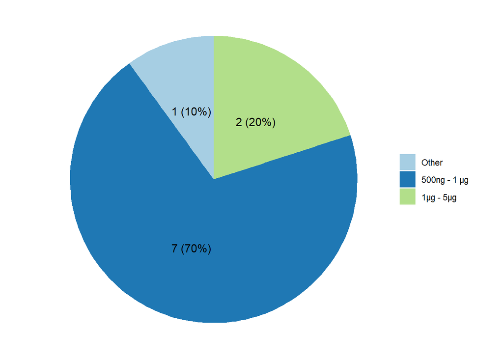

| Category | Comment |
| --- | --- |
| Other | Auswahl im Referenzlabor Kiel |

## 13.3 What level of sensitivity is typically achieved in your MRD analysis?

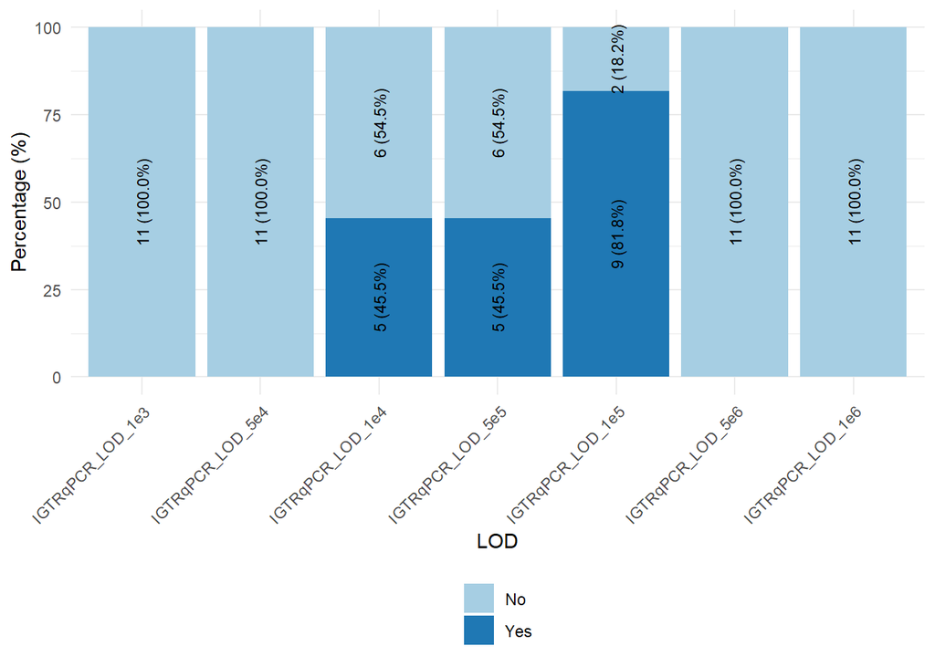

## 13.4 What quantitative range is typically achieved in your MRD analysis?

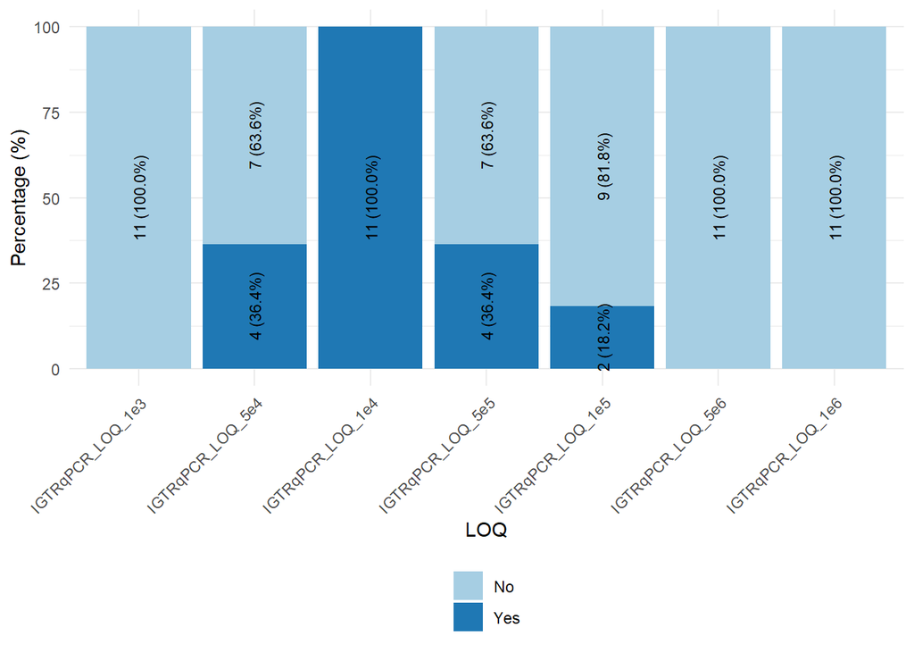

## 13.5 How do you report results that are above the sensitivity threshold but below the quantitative range?

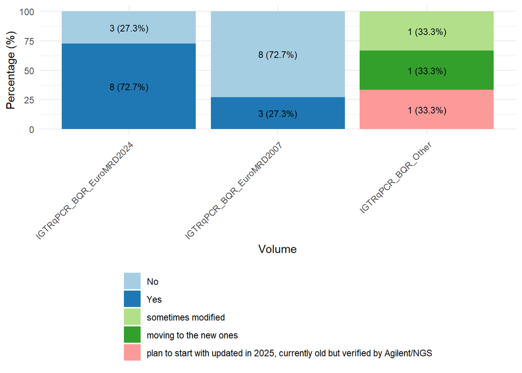

# 14 Technical Requirements IG/TR ddPCR

## 14.1 Which anticoagulant do you use for bone marrow samples intended for IG/TR-based ddPCR MRD analysis?

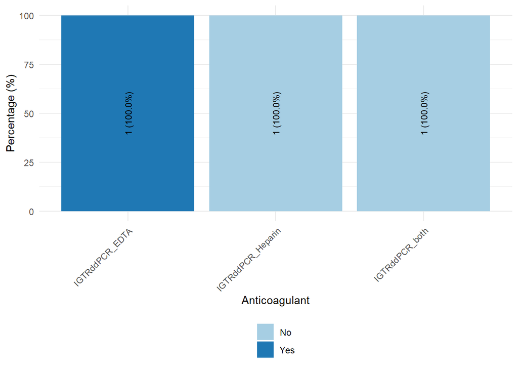

## 14.2 What is the minimum DNA amount you typically analyze per molecular target?

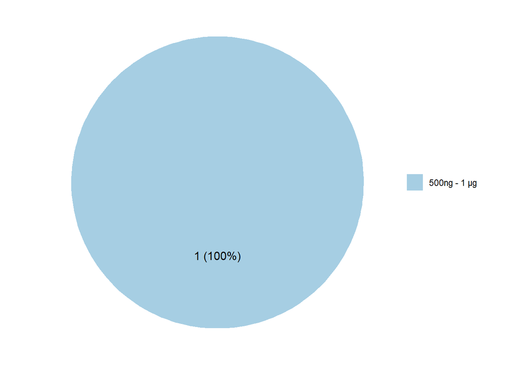

```
## No comments available.
```

## 14.3 What is the minimum number of events required to define MRD positivity?

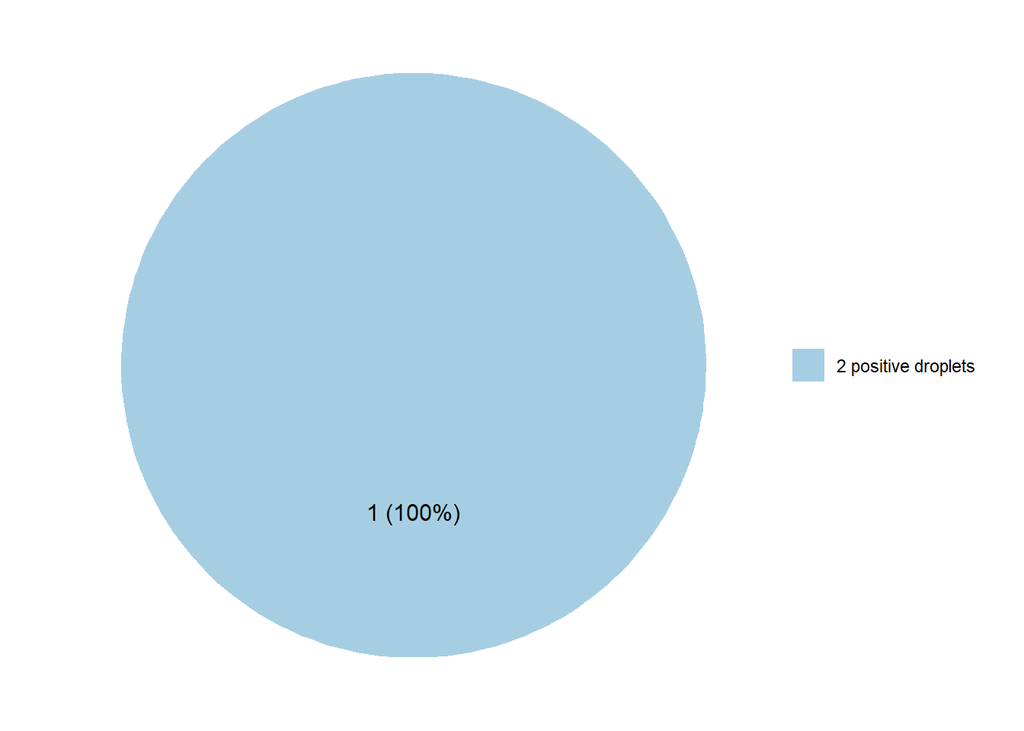

```
## No comments available.
```

## 14.4 What level of sensitivity is typically achieved in your MRD analysis?

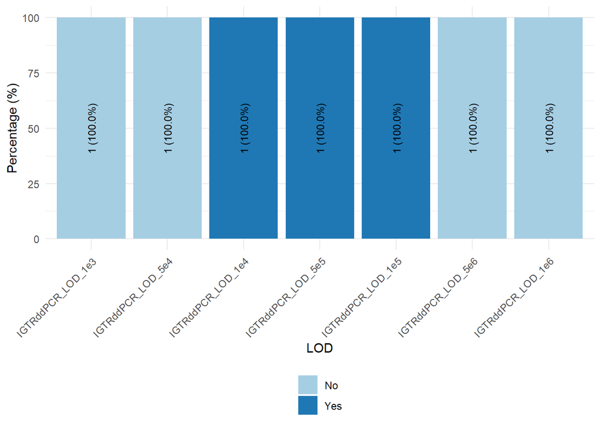

## 14.5 Do you account for background noise from healthy cells in your MRD analysis?

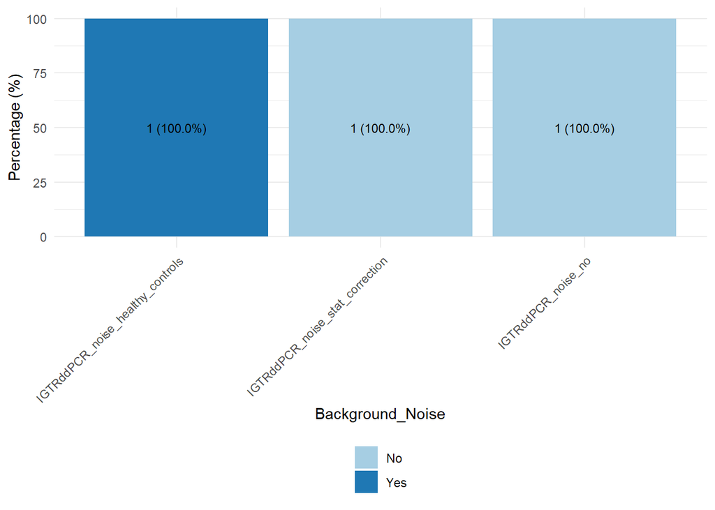

## 14.6 Do you use a commercial assay or an in-house assay for your MRD analysis?

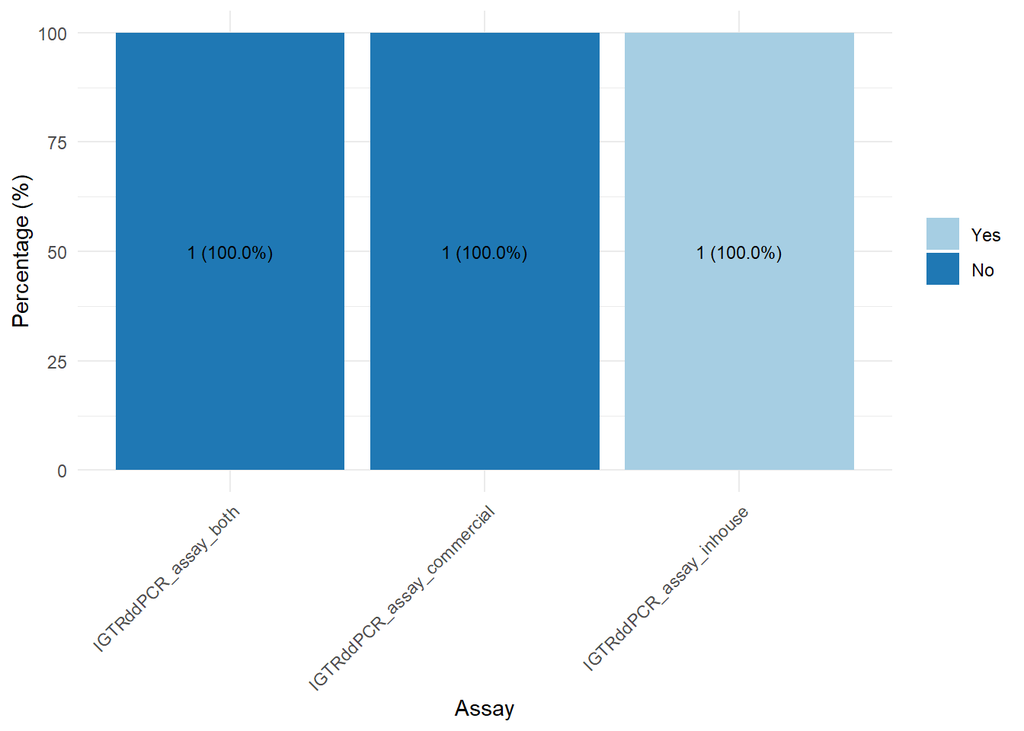

```
## No comments available.
```

# 15 Technical Requirements IG/TR amplicon NGS

## 15.1 Which anticoagulant do you use for bone marrow samples intended for IG/TR-based NGS MRD analysis?

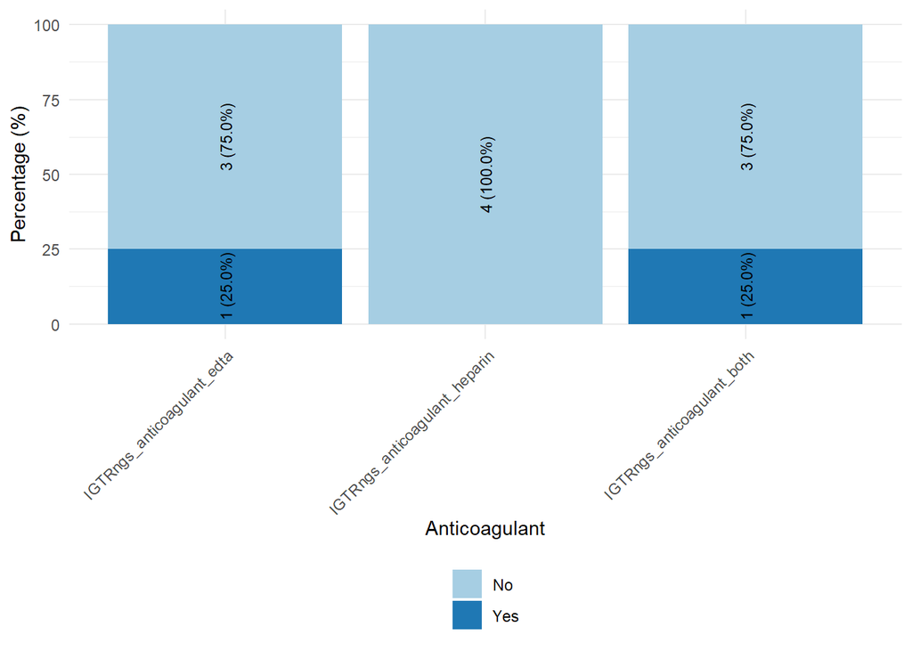

## 15.2 What is the minimum DNA amount you typically analyze per sequencing library reacion?

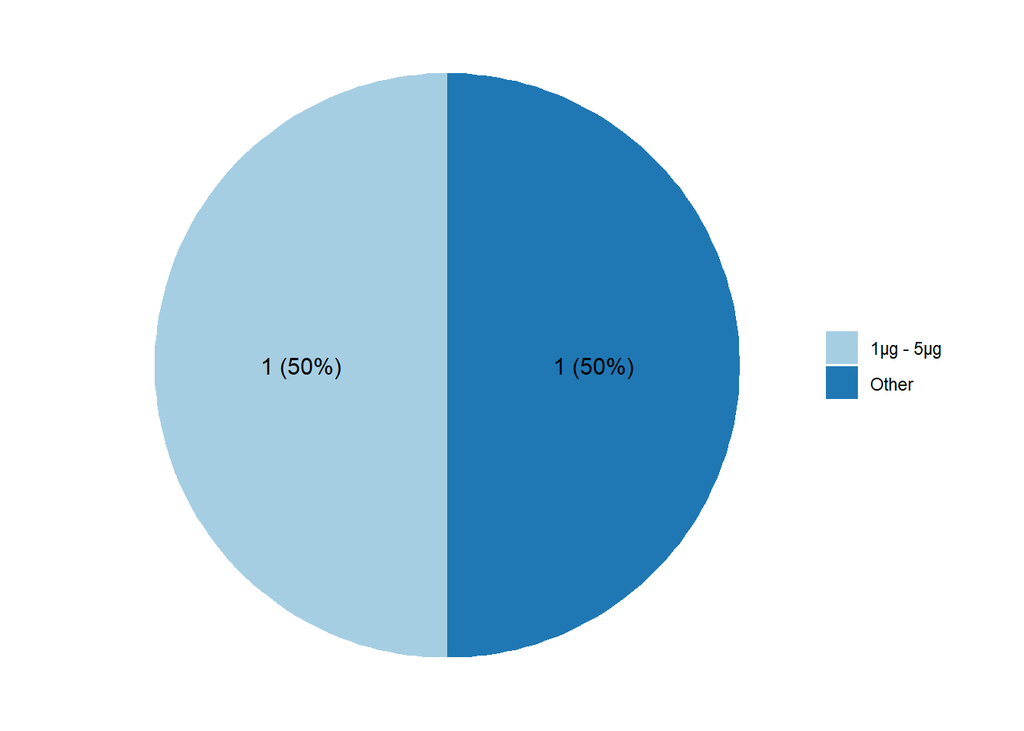

| Category | Comment |
| --- | --- |
| Other | This is centrally done and we are not privy to the amount needed |

## 15.3 What is the minimum number of reads required to define MRD positivity?

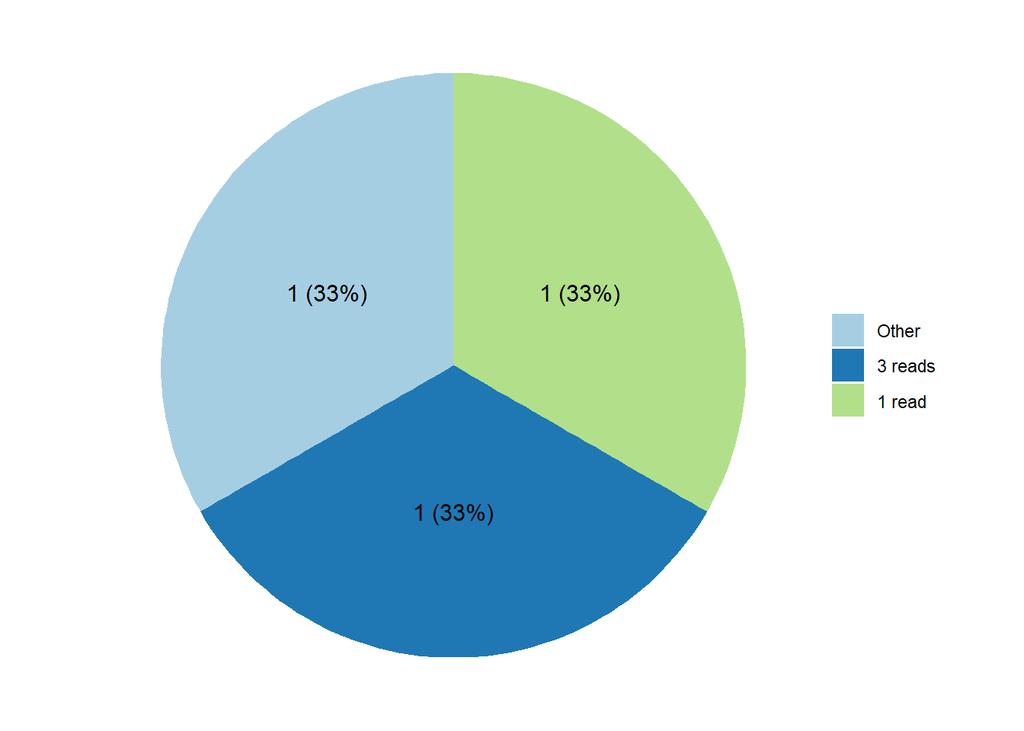

| Category | Comment |
| --- | --- |
| Other | This is proprietary and we are not provided it |

## 15.4 What level of sensitivity is typically achieved in your MRD analysis?

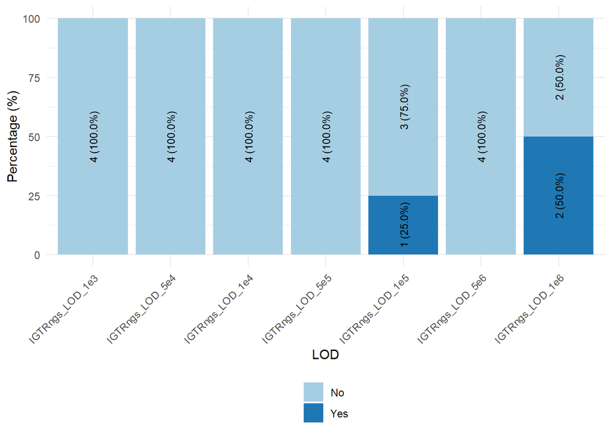

## 15.5 What quantitative range is typically achieved in your MRD analysis?

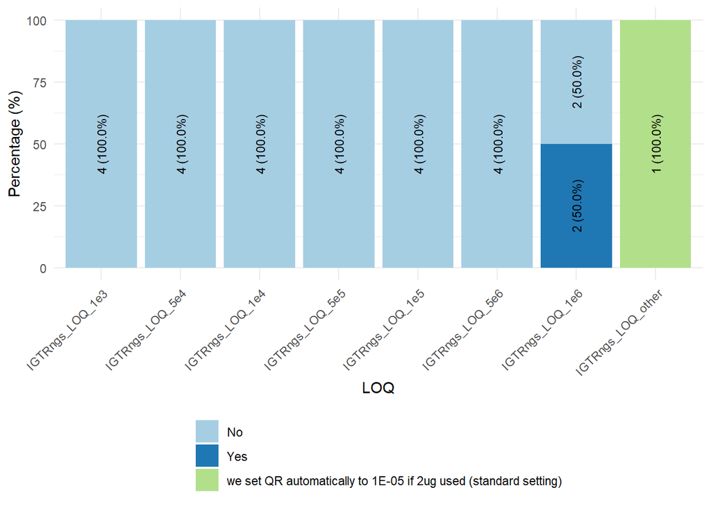

## 15.6 Do you account for background noise from healthy cells in your MRD analysis?

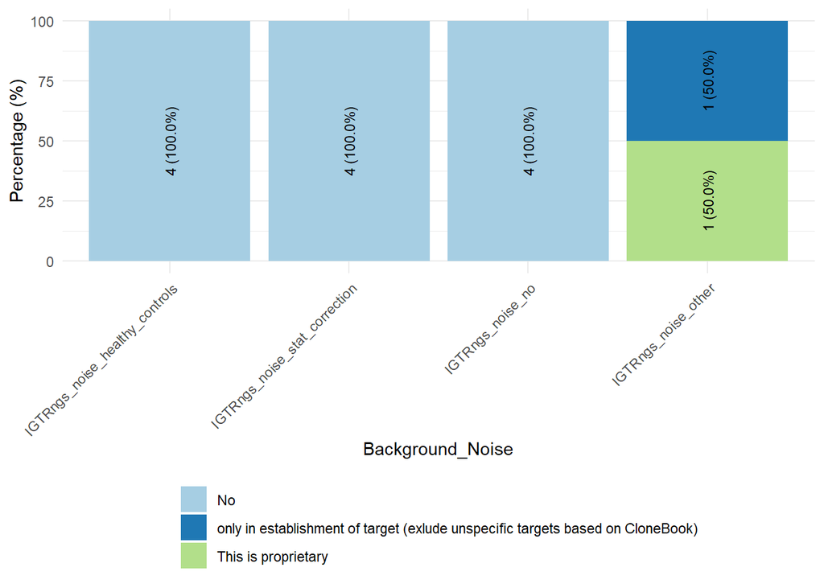

## 15.7 Do you use a commercial assay or an in-house assay for your MRD analysis?

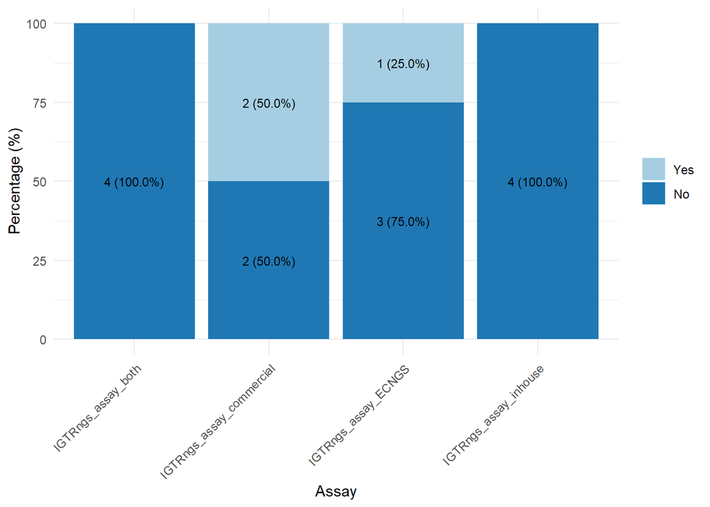

| Category | Comment |
| --- | --- |
| Commercial | clonoSEQ |
| Commercial | Clonoseq |

# 16 Technical requirements KMT2A qPCR

Statement 43: A DNA-based KMT2A assay should be used for MRD analysis to avoid inconsistencies due to variable expression levels that can affect RNA-based assays.

## 16.1 Which anticoagulant do you use for bone marrow samples intended for KMT2A-based qPCR MRD analysis?

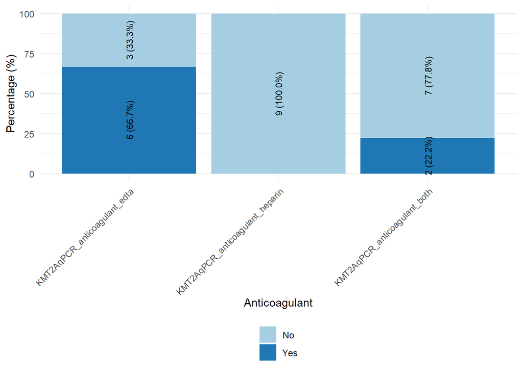

## 16.2 What is the minimum DNA amount you typically analyze per reaction?

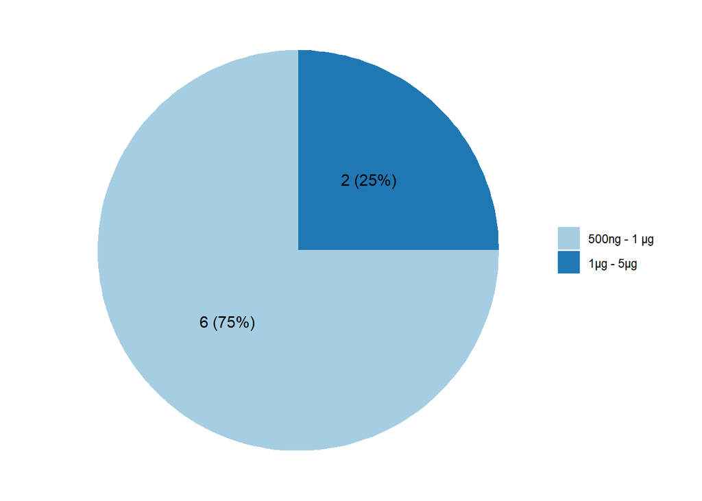

| Category | Comment |
| --- | --- |
| NA | Auswahl im Referenzlabor Kiel |

## 16.3 What level of sensitivity is typically achieved in your MRD analysis?

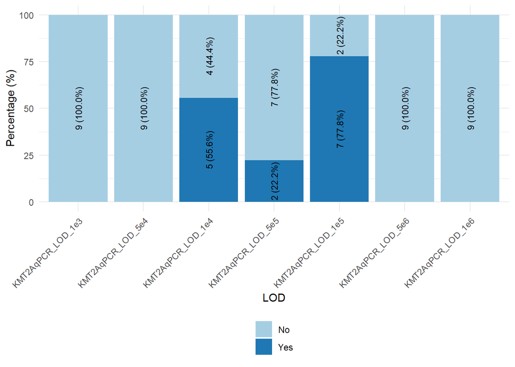

## 16.4 What quantitative range is typically achieved in your MRD analysis?

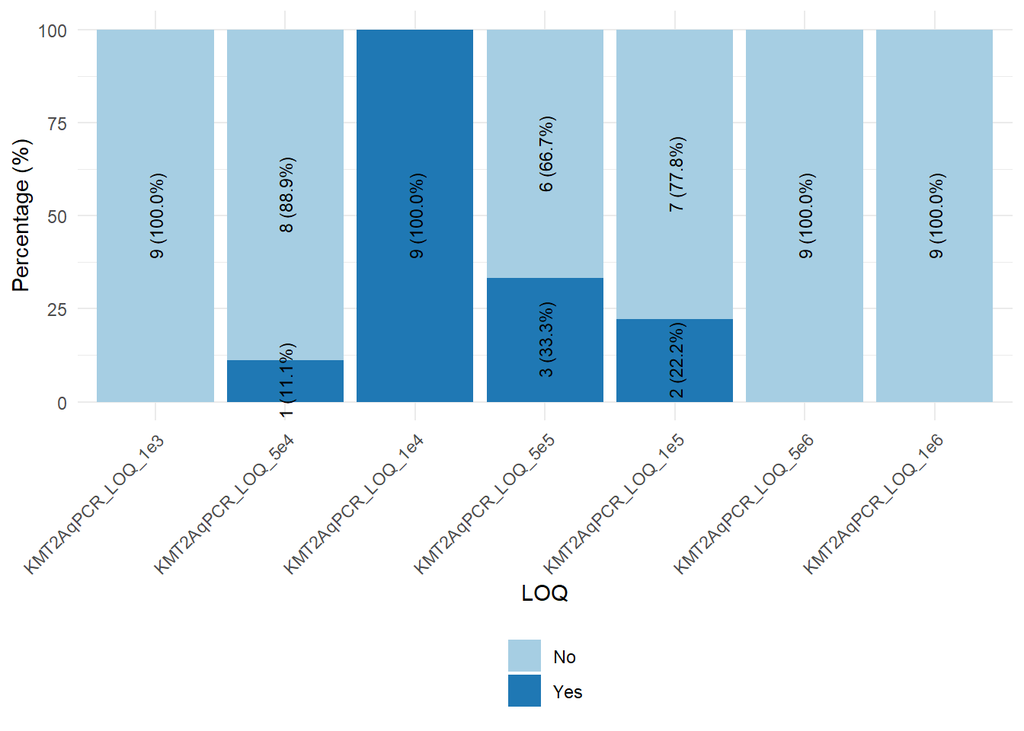

## 16.5 Do you account for background noise from healthy cells in your MRD analysis?

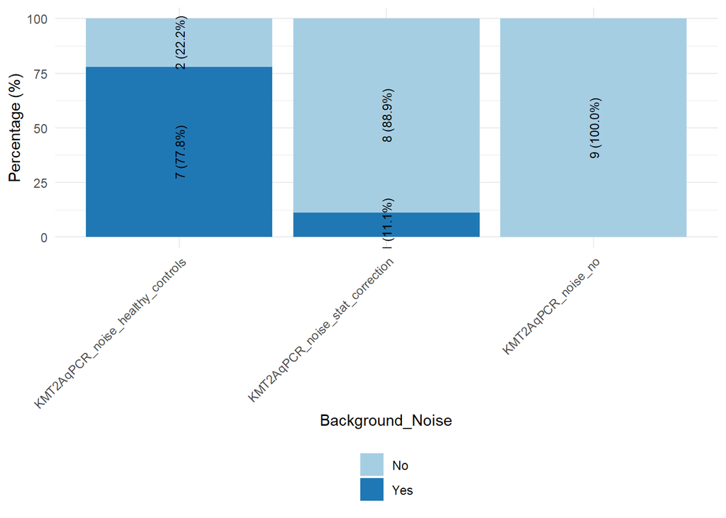

## 16.6 Do you use a commercial assay or an in-house assay for your MRD analysis?

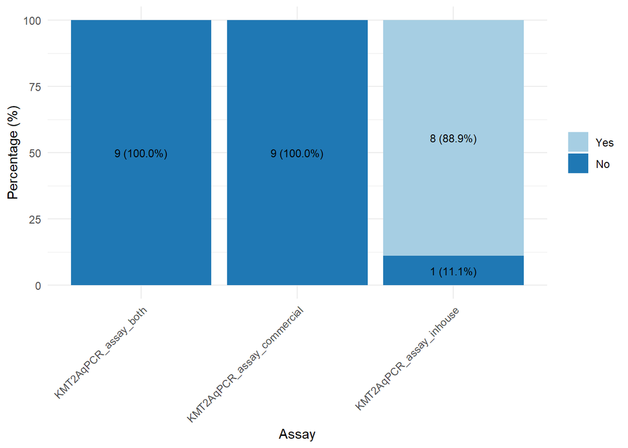

| Category | Comment |
| --- | --- |
| In-house | RT-PCR; note, we use RNA rather than DNA |
| In-house | patient-specific assays |

# 17 Technical Requirements KMT2A ddPCR

no responses

# 18 Technical Requirements DNA-based BCR::ABL1 qPCR

## 18.1 Which anticoagulant do you use for bone marrow samples intended for BCR::ABL1-based qPCR MRD analysis?

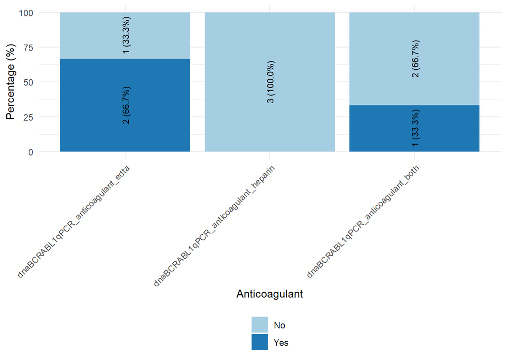

## 18.2 Which housekeeping gene do you use for BCR::ABL1 qPCR normalization?

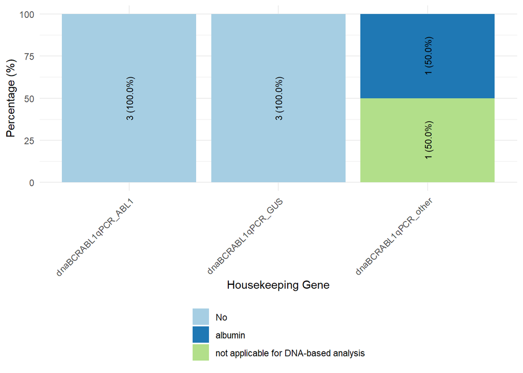

## 18.3 How many copies of the housekeeping gene do you typically aim for in BCR::ABL1 transcript quantification?

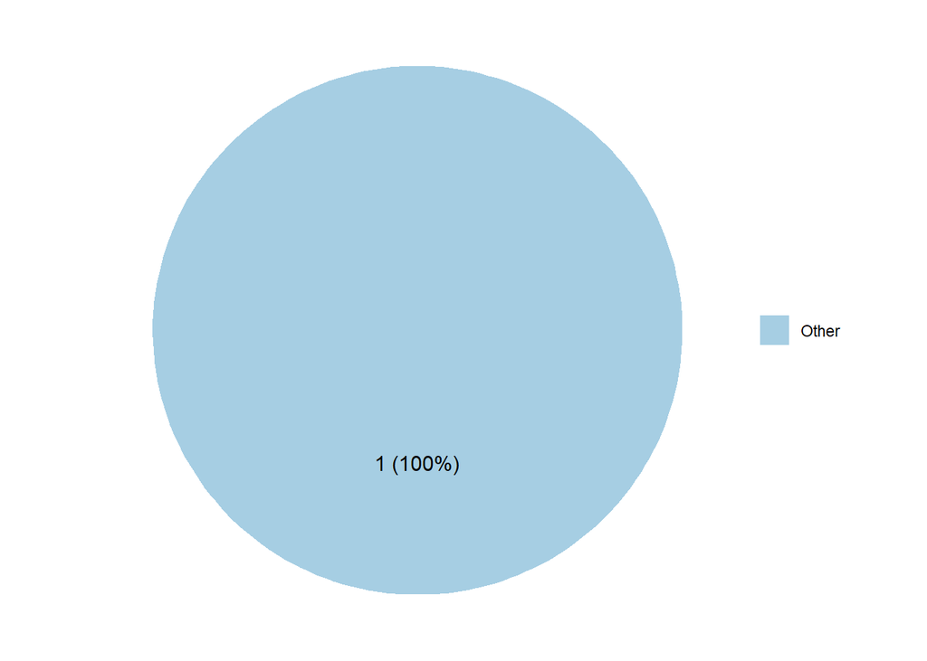

| Category | Comment |
| --- | --- |
| Other | depends on situation (we use GUSB) |
| NA | not applicable for DNA-based analysis |

## 18.4 How do you quantify the housekeeping gene as the denominator for BCR::ABL1 MRD assessment:

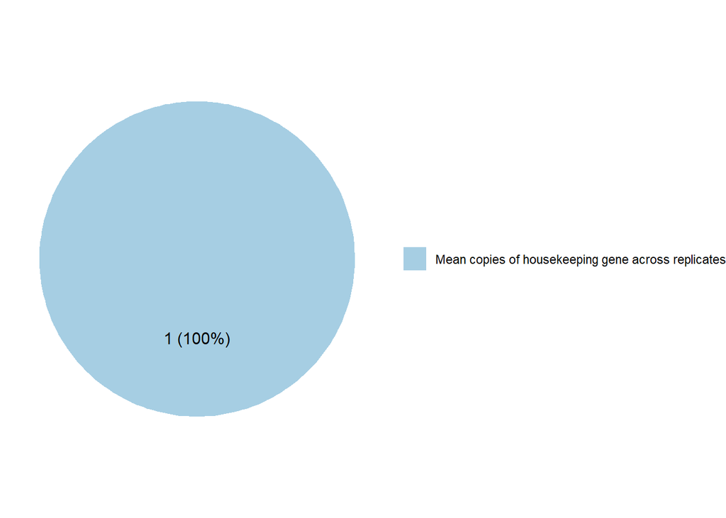

| Category | Comment |
| --- | --- |
| NA | not applicable for DNA-based analysis |

## 18.5 What is the source of the plasmids you use for BCR::ABL1 quantification?

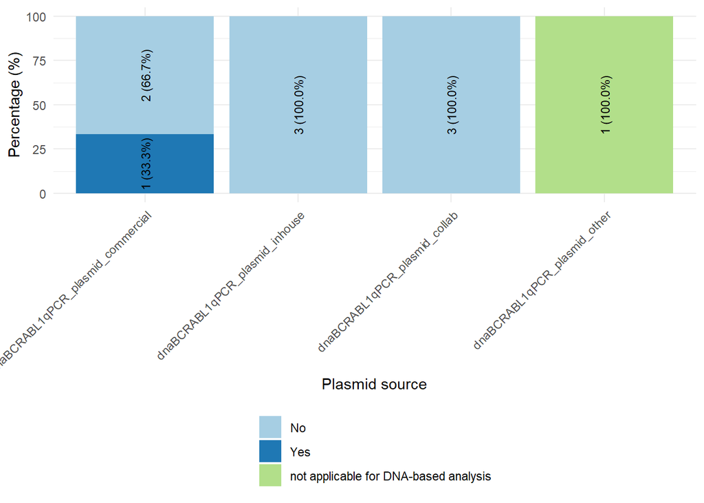

## 18.6 What is the minimum number of positive replicates required to define MRD positivity?

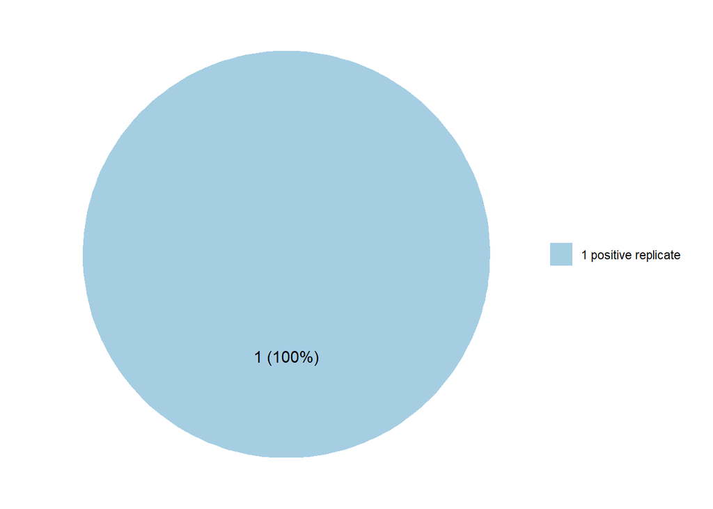

| Category | Comment |
| --- | --- |
| NA | not applicable for DNA-based analysis |

## 18.7 How do you report the MRD value for the major BCR::ABL1 transcripts?

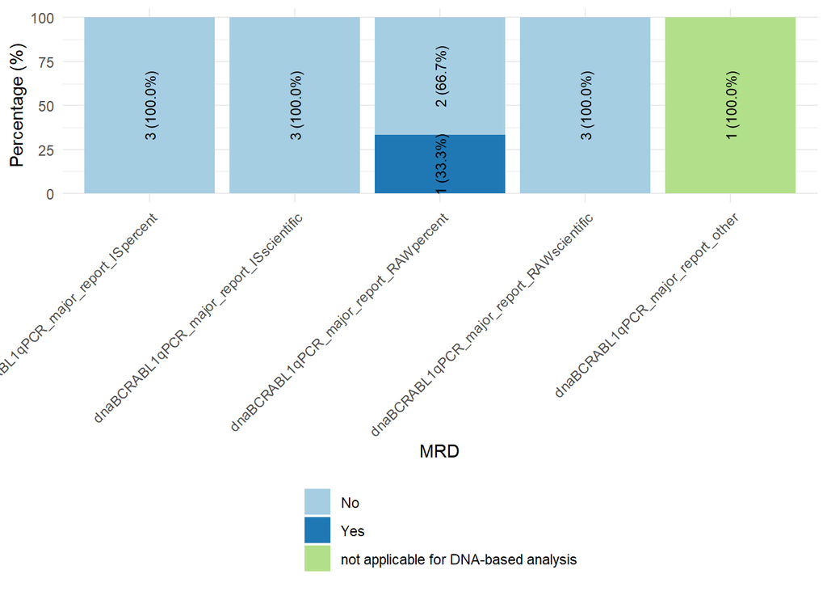

## 18.8 How do you report the MRD value for the minor BCR::ABL1 transcripts?

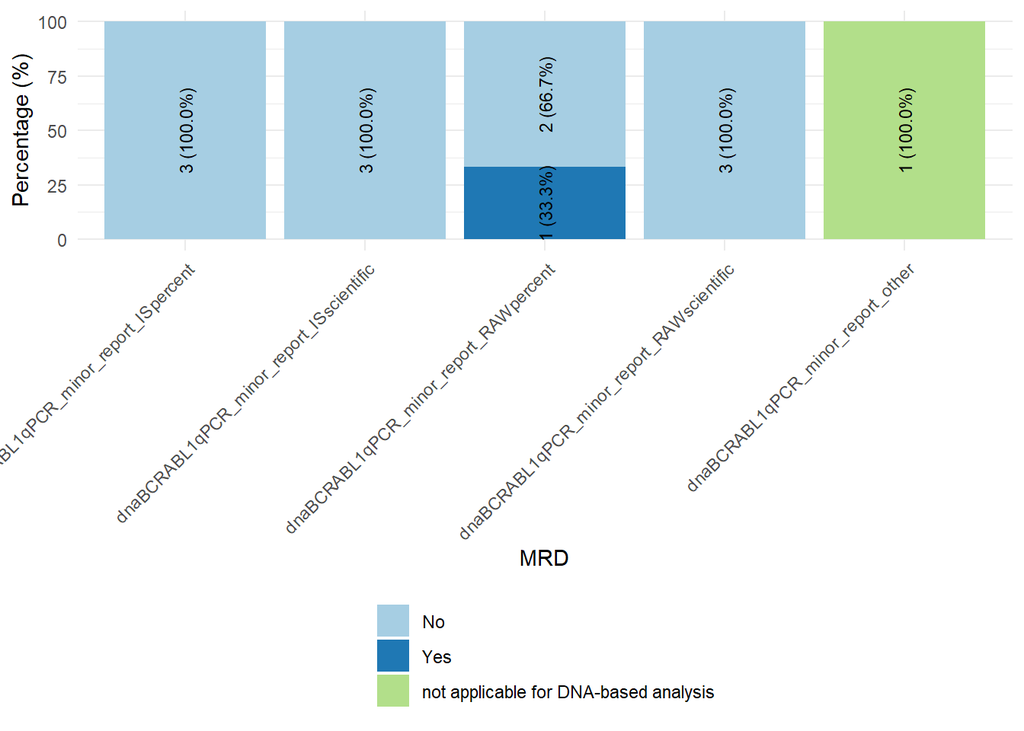

## 18.9 Do you use the CML MRD nomenclature to interpret BCR::ABL1-MRD results in Ph+ ALL (MMR, MR4, MR4.5, MR5)?

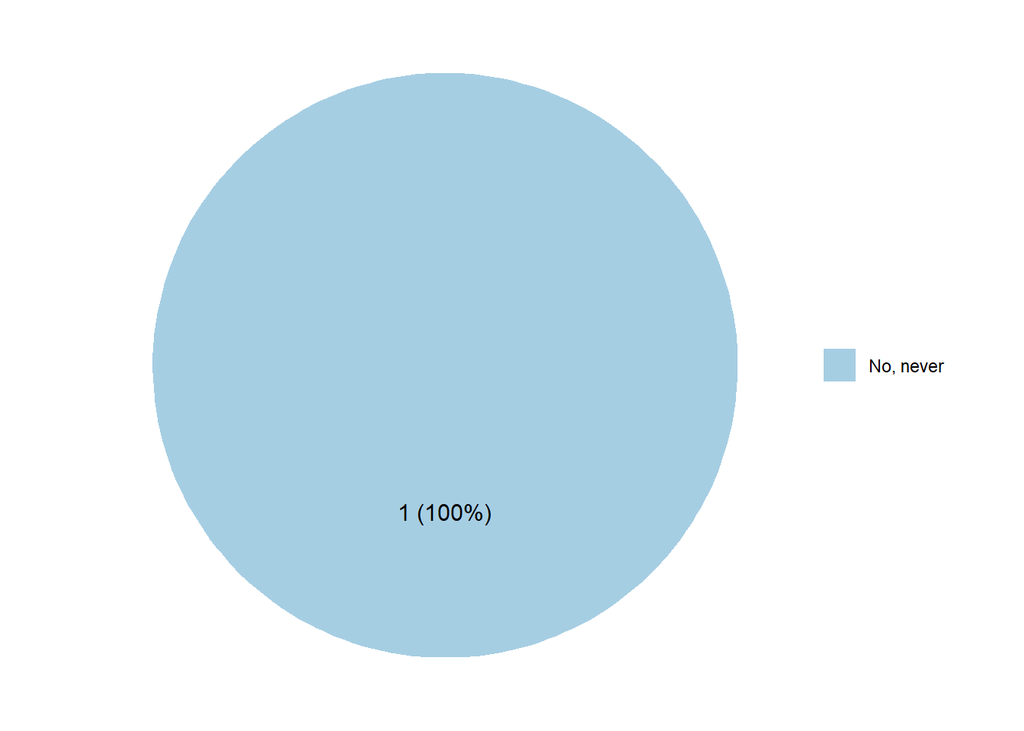

| Category | Comment |
| --- | --- |
| NA | not applicable for DNA-based analysis |

## 18.10 Do you use a commercial assay or an in-house assay for major BCR::ABL1-transcript-based MRD analysis?

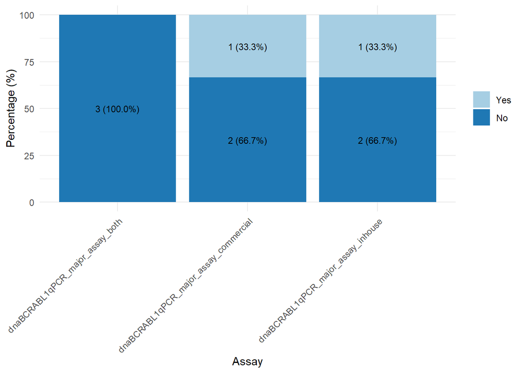

| Category | Comment |
| --- | --- |
| In-house | patient-specific assay |

## 18.11 Do you use a commercial assay or an in-house assay for minor BCR::ABL1-transcript-based MRD analysis?

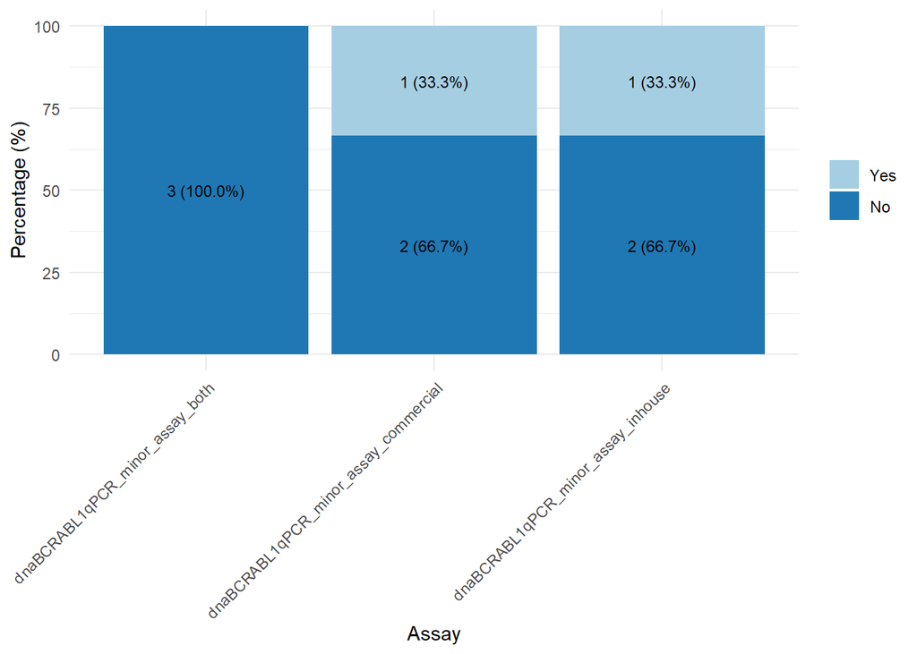

| Category | Comment |
| --- | --- |
| In-house | patient-specific assay |